# Time Series Homework: Chapter 2 Lesson 1

Tristan Farrow

## Data

```r
okuns <- rio::import("https://byuistats.github.io/timeseries/data/outputgap_and_cyclical_unemp.xlsx")

gs_night <- rio::import("https://byuistats.github.io/timeseries/data/nightstand-sweat.csv")
```

## Questions

### Question 1 - Context and Measurement (10 points)

The first part of any time series analysis is context. You cannot properly analyze data without knowing what the data is measuring. Without context, the most simple features of data can be obscure and inscrutable. This homework assignment will center around the series below.

Please research the time series. In the spaces below, give the data collection process, unit of analysis, and meaning of each observation for the series.

#### a) **Output Gap**

https://chat.openai.com/share/122aaad9-2be6-43ec-b58a-e1858305b401

**Answer**

#### b) **Cyclical Unemployment**

https://chat.openai.com/share/7d6bf187-41d0-42c3-98bc-d02ea1bd5b80

**Answer**

Unemployment is measured through the Current Population Survey (CPS), conducted monthly by the U.S. Census Bureau. The survey samples approximately 60,000 eligible households across diverse geographic regions in the United States.

Okun’s Law is an empirical relationship defined as a negative correlation between the Output Gap and Cyclical Unemployment. If the economy is expanding, businesses are producing more, and unemployment tends to decrease. Conversely, during economic contractions or recessions, output shrinks, leading to an increase in unemployment.

Please use the data *okuns* to test whether Okun’s Law applies to the US from 1960 to 2021.

##### a) Please create a scatter plot of the Output Gap in the x-axis and Cyclical Unemployment in the y-axis.

**Answer**

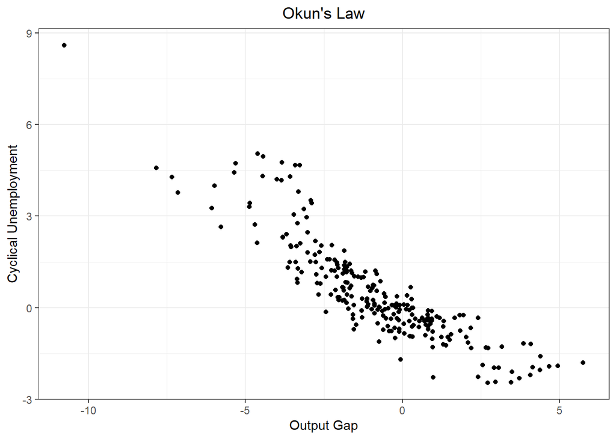

```r
ggplot(
  data = okuns,
  aes(x = `Output Gap`, y = `Cyclical Unemployment`)
) +
  geom_point() +
  labs(
    title = "Okun's Law"
  ) +
  theme_bw() +
  theme(
    plot.title = element_text(hjust = 0.5)
  )
```

##### b) Please calculate the covariance and correlation coefficient between the Output Gap and Cyclical Unemployment.

**Answer**

```r
gap_umep_cor <- cor(okuns$`Output Gap`, okuns$`Cyclical Unemployment`)
gap_umep_cov <- cov(okuns$`Output Gap`, okuns$`Cyclical Unemployment`)

print(paste("Covariance: ",gap_umep_cov))
```

```
[1] "Covariance:  -3.53117171859143"
```

```r
print(paste("Correlation",gap_umep_cor))
```

```
[1] "Correlation -0.886197817692177"
```

##### c) Evaluate Okun’s law. Is there sufficient evidence to suggest an empirical relationship between the Output Gap and Cyclical Unemployment?

**Answer**

The correlation between the 2 factors is -0.886 if rounded to the third decimal point. Correlation ranges between -1 and 1 and so this is a very strong negative correlation. Okun’s law is the defined by the inverse relationship between Output Gap and Cyclical Unemployment and so it appears to be reaffirm by this data.

### Question 3 - Correlation vs Causation: Spurious Searches (30 points)

*“Every single person who confuses correlation and causation ends up dying.”*

Hannah Fry

Please use the data *gs_night* to evaluate the empirical relationship between the Google search terms for *night sweats* and *nightstand.*

**Answer**

[figure not shown]

```r
ggplot(
  data = gs_night,
  aes(x = nightstand, y = `night sweat`)
) +
  geom_point() +
  labs(
    title = "Google Searches for Night Sweat and Night Stand",
    x = "Number of Google searches for nightstand",
    y = "Number of Google searches for night sweat"
  ) +
  theme_bw() +
  theme(
    plot.title = element_text(hjust = 0.5)
  )
```

##### b) Please calculate the covariance and correlation between the night sweat search index and the nightstand search index.

**Answer**

```r
night_cov <- cov(gs_night$nightstand, gs_night$`night sweat`)
night_cor <- cor(gs_night$nightstand, gs_night$`night sweat`)

print(paste("Covariance: ", night_cov))
```

```
[1] "Covariance:  271.049982710927"
```

```r
print(paste("Correlation: ", night_cor))
```

```
[1] "Correlation:  0.787151766251033"
```

##### c) Please suggest a scenario where an increase in the frequency of searches for nightstand will cause higher searches for the term night sweats?

**Answer**

Tech nightstands have heating issues from charging phones leading to hot rooms at night.

##### d) Please suggest a scenario where an increase in the frequency of searches for night sweats will cause higher searches for the term nightstand?

**Answer**

Nightstand fans ads are targeted for people searching the words “night sweats”.

##### e) Please suggest an event or reason that would result in the correlation between searches for night sweats and searches for the term nightstand?

**Answer**

A seasonal heatwave has people looking for nightstand fans to cool them off at night.

##### f) Are any of your suggestions plausible? What does that teach you about the difference between correlation and causation? Please elaborate.

**Answer**

These are not very plausible and rather funny. Correlation and causation can be connected but it takes more evidence than correlation to show causation.

### Rubric

[output not shown]